# NHS Borders Cancer

D. Bradshaw

2022-12-01

In general the data shows slightly more men being diagnosed with Cancer than women in more recent years though more women overall. The mean rate however remains higher in males.

```r
by_age %>%
  filter(cancer_site == "All cancer types") %>%
  pivot_longer(cols = c(incidences_age_under5:incidences_age85and_over), names_to = "age_range", values_to = "incidences") %>%
  group_by(sex) %>%
  summarise(total_for_gender_16_to_20 = sum(incidences))
```

| sex | total_for_gender_16_to_20 |
| --- | --- |
| All | 4065 |
| Female | 1991 |
| Male | 2074 |

```r
by_year %>%
  filter(cancer_site == "All cancer types") %>%
  group_by(sex) %>%
  summarise(total_for_gender_96_to_20 = sum(incidences_all_ages))
```

| sex | total_for_gender_96_to_20 |
| --- | --- |
| All | 18091 |
| Female | 9113 |
| Male | 8978 |

```r
by_year %>%
  filter(cancer_site == "All cancer types") %>%
  group_by(sex) %>%
  summarise(mean_rate_96_to_20 = mean(crude_rate))
```

| sex | mean_rate_96_to_20 |
| --- | --- |
| All | 649.0861 |
| Female | 633.6227 |
| Male | 665.5242 |

Looking at some demographic I have chosen to highlight some of the most common cancer types broken down by gender. We can see that Non-melanoma skin cancer is high for both males and females, though far higher in males. Breast cancer and prostate cancer are significant risks for the respective genders.

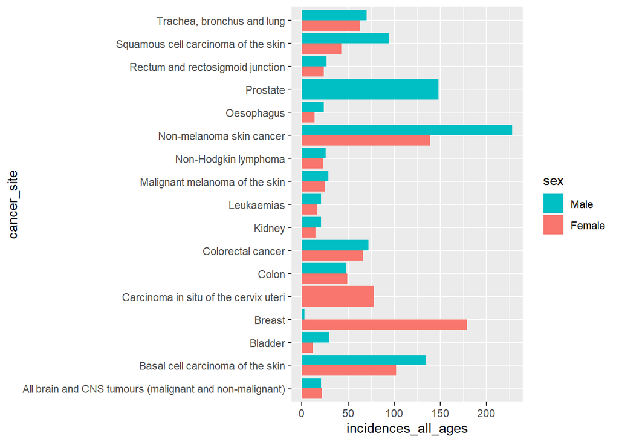

Chose to look at the cancers causing the most incidences in males, females and across genders.

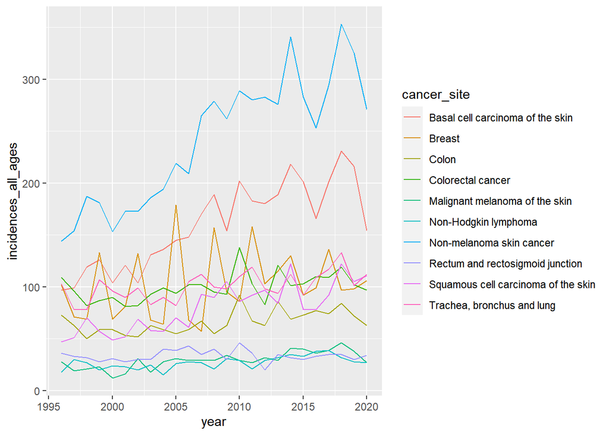

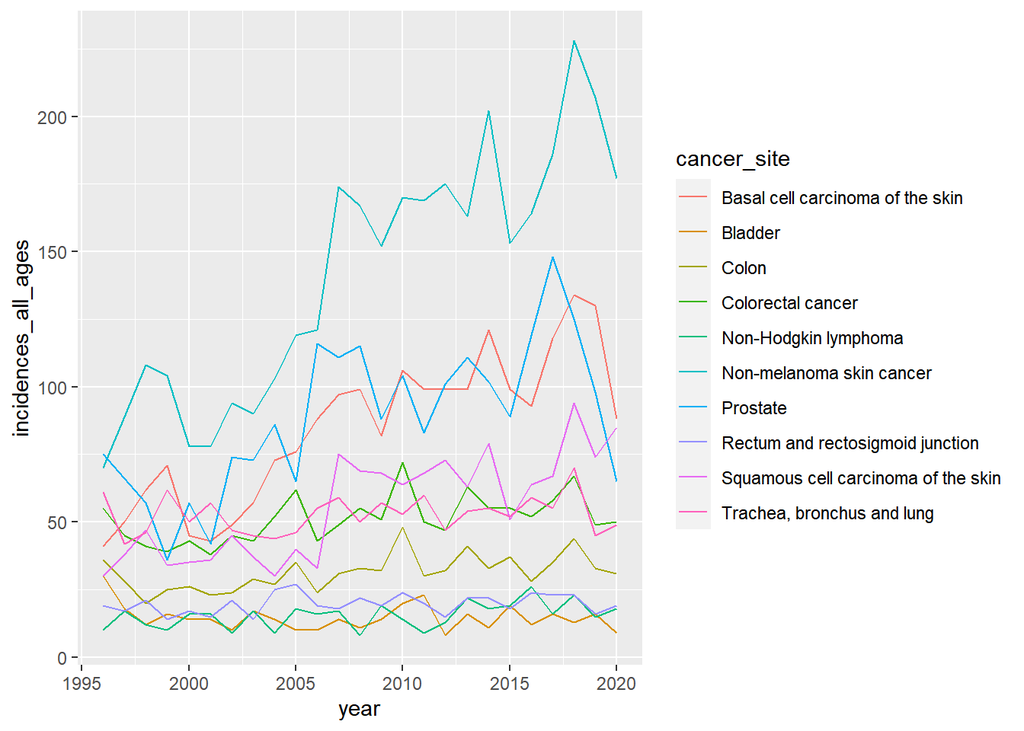

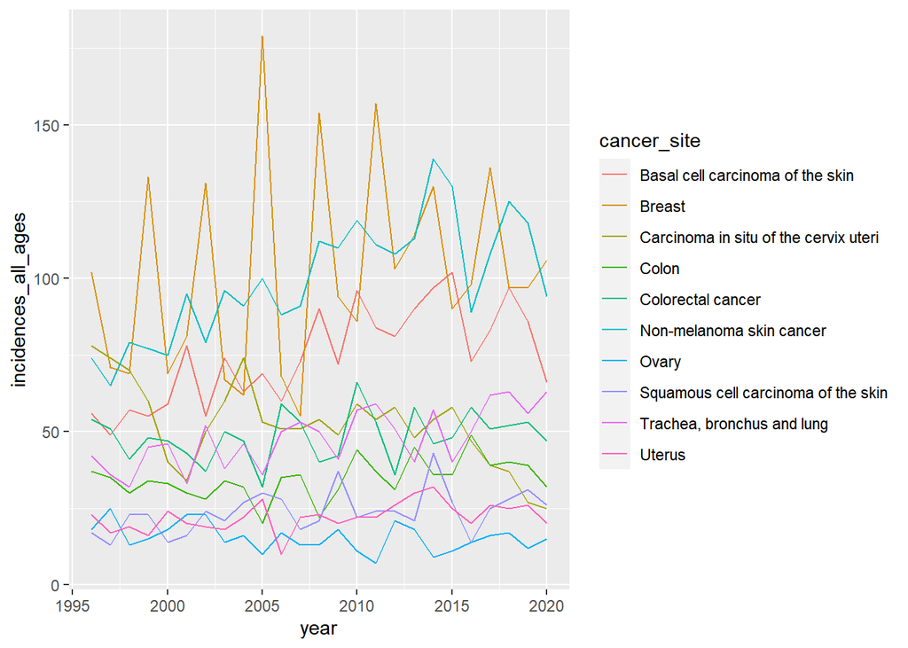

There is an interesting pattern in the incidences of breast cancer with peaks every 3 years across the data set. With GP practices performing a screening program every 3 years it seems plausible that these are linked and the rise in cases relates to additional screening across the area of NHS borders.

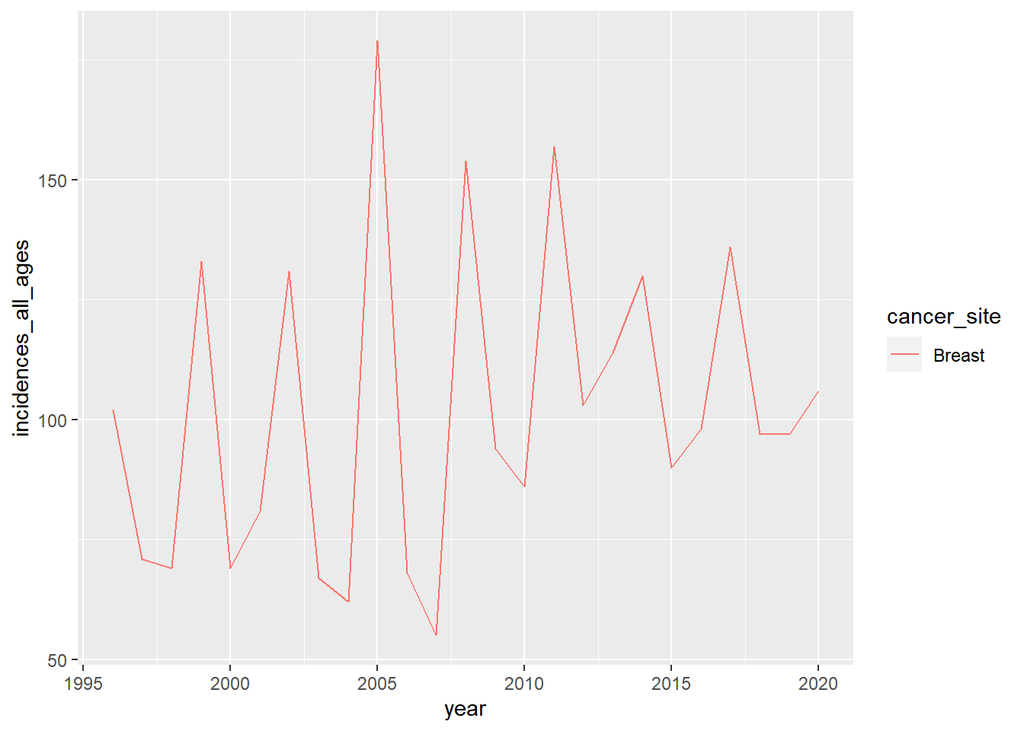

PLotting the instances of the least common types of cancer against the EASR shows that we would not expect massively different numbers from those we are seeing. This is a good indication that this is not due to failure to diagnose.

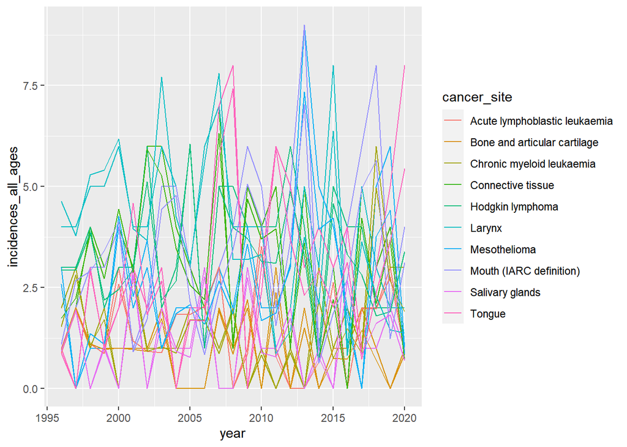

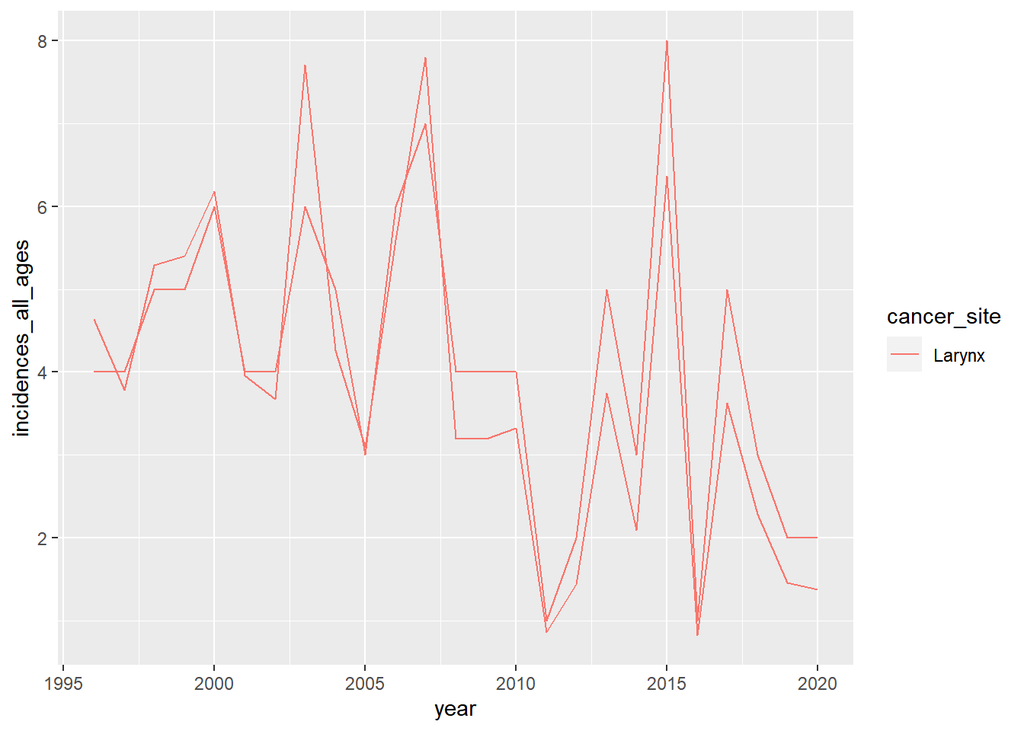